# UTLK Phosphorus Methods review

T.Hooker

11 July, 2019

**Project Root Path** :: `"U:\ENG_WQ\tobyhooker\DATA MANAGEMENT & QA\DATA.Projects\UtahLake_chemMethods\UTLK_DP_meth_r"`

```r
#options(table_counter=FALSE)
tidy_package <- c("plyr", "dplyr", "tidyr", "magrittr", "htmlTable")
# suppressPackageStartupMessages(library("tidy"))
if(!"tidyr" %in% (.packages())) {invisible(lapply(tidy_package, function(x) suppressMessages(library(x, character.only=T, quietly = T, warn.conflicts = F))))}
##
graph_package <- c("ggplot2", "scales")
if(!"ggplot2" %in% (.packages())) {invisible(lapply(graph_package, library, character.only=T, quietly = T, warn.conflicts = F))}
##
options(scipen = 999, digits = 4, stringsAsFactors = FALSE, keep.source = TRUE)
##
# startwork.date <- format(Sys.Date(), "%y%m%d")
knitr::opts_chunk$set(cache=TRUE)
```

## 0.0 Notes

[190711] :: Utah Lake Science Panel posed question of what happened to DP methods or chemical-analysis approach b/w 1999-2007 vs. 2007-current, where an observed baseline of 10 ppb DP increased toward 30-40 ppb after 2007 (approximately).

Steps:

1. Extract all P data from AWQMS from UTLK sites
2. Eval Meth-Params over time
3. Eval RLs over time

## 1.0 Data import

1. UTLK Sites

```r
## [2; paste vector from ClipBoard to DF / vector]
# readClipboard()-> utlk_sites
```

2. Use these sites to pull full Standard Export from AWQMS for all P-related parameters

Go to : https://awqms.utah.gov/Homepage.aspx  
Login as: thooker // pw  
Navigate :

- Metadata
- Monitoring Locations
- [select] Search
- [select] Export to Excel
- -complete-
3. Import AWQMS data

```r
# file.01  <- choose.files(caption="Select _working_ DATA file [*.xlsx]", multi = FALSE)
data01 <- openxlsx::read.xlsx(file.01, sheet=1, startRow = 2,
                              rowNames=FALSE, check.names = T)
```

4. Cleanup and Tune
- Sampling and Analysis Date/Time

```r
data01$Activity.Start.Date <- as.Date(data01$Activity.Start.Date, origin="1899-12-30")
data01$Analysis.Start.Date <- as.Date(data01$Analysis.Start.Date, origin="1899-12-30")
data01$Activity.Start.Time <- as.character(chron::times((data01$Activity.Start.Time - as.integer(data01$Activity.Start.Time))))
data01$Analysis.Start.Time <- as.character(chron::times((data01$Analysis.Start.Time - as.integer(data01$Analysis.Start.Time))))
```

- Filename :: Standard Export 24049.xlsx
- Path :: C:/R_PROJECT_WORK_4
- Datafile has :: 4511 records & 191 fields
- Record Data Range :: From 1978-08-31 to 2018-11-20
- Record Sample-Time Range :: From [07:30:00] to [17:35:00]

### 1.1 Trim datafile

**Fields to Keep from AWQMS Standard Export**

```r
awqms_export_fields_tokeep <- c("Organization.ID","Activity.ID","Activity.Type","Activity.Media","Activity.Start.Date", "Activity.Start.Time", "Activity.Relative.Depth","Activity.Depth.Height","Activity.Depth.Height.Unit","Activity.Top.Depth.Height","Activity.Top.Depth.Height.Unit","Activity.Bottom.Depth.Height","Activity.Bottom.Depth.Height.Unit","Project.ID1","Project.ID2","Activity.Conducting.Organization1","Activity.Conducting.Organization2","Monitoring.Location.ID","Monitoring.Location.Name","Monitoring.Location.Type","Activity.Comment","Sample.Collection.Method.ID","Sample.Collection.Method.Context","Sample.Collection.Method.Name","Sample.Collection.Method.Description","Result.UID","Data.Logger.Line","Detection.Condition","Characteristic.Name","Method.Speciation","Sample.Fraction","Result.Value","Result.Unit","Result.Qualifier","Result.Status","Value.Type","Time.Basis","Temperature.Basis","Result.Comment","Result.Depth.Height","Result.Depth.Height.Unit","Analytical.Method.ID","Analytical.Method.Context","Analytical.Method.Name","Analytical.Method.Qualifier","Analytical.Method.Description","Laboratory.Name","Analysis.Start.Date","Analysis.Start.Time","Analysis.Start.Time.Zone","Laboratory.Comment.Code","Detection.Limit.Type1","Detection.Limit.Value1","Detection.Limit.Unit1","Detection.Limit.Type2","Detection.Limit.Value2","Detection.Limit.Unit2","Laboratory.Accreditation.Indicator","Substance.Dilution.Factor1","Lab.Batch.ID","Lab.Sample.ID")
```

```r
data01 %>% select(., awqms_export_fields_tokeep) -> data02
# Simplify VarNames
data02 %<>% select(ORG = Activity.Conducting.Organization1,
                   ACTID = Activity.ID,
                   ACT.type = Activity.Type,
                   SDate = Activity.Start.Date, STime = Activity.Start.Time,
                   ACT.depth = Activity.Relative.Depth,
                   PROJ01 = Project.ID1,
                   MLID = Monitoring.Location.ID,
                   MLID.name = Monitoring.Location.Name,
                   MLID.type = Monitoring.Location.Type,
                   ACT.comment = Activity.Comment,
                   DLL = Data.Logger.Line,
                   MethodID = Analytical.Method.ID,
                   PARAM = Characteristic.Name,
                   SampFrac = Sample.Fraction,
                   DetCond = Detection.Condition,
                   ResQual = Result.Qualifier,
                   Result.Value, Result.Status, Result.Comment, Value.Type,
                   Limit01_nm = Detection.Limit.Type1,
                   Limit01_val = Detection.Limit.Value1,
                   Limit02_nm = Detection.Limit.Type2,
                   Limit02_val = Detection.Limit.Value2,
                   DilFact = Substance.Dilution.Factor1,
                   Method_desc = Analytical.Method.Description,
                   LAB = Laboratory.Name,
                   AnalysisDate = Analysis.Start.Date,
                   BatchID = Lab.Batch.ID,
                   PROJ02 = Project.ID2, everything()
                   )
## arrange Var's
data02 %<>% select(-ORG, -ACTID, -PROJ01, everything()) %>%
  select(ACT.type:ResQual, Result.Status,
         Result.Value, Limit01_nm, Limit01_val, Limit02_nm, Limit02_val, DilFact,
         everything())
```

### 1.2 Cleanup Methods and Params

**Parameters**

```r
unique(data02$PARAM)
```

[output not shown]

```r
data02 %<>% mutate(ParamX = PARAM) %>%
  mutate(ParamX = recode(.$PARAM,
                         "Calcium" = "CA",
                         "Phosphate-phosphorus" = "TP",
                         "Alkalinity, total" = "T.Alk",
                         "Total suspended solids" = "TSS",
                         "Total volatile solids" = "TVS")) %>%
  select(ACT.type:PARAM, ParamX, everything())
```

```r
unique(data02$MethodID)
```

[output not shown]

```r
unique(data02$SampFrac)
```

```
[1] "Dissolved" "Total"     NA
```

```r
table(data02$SampFrac, useNA="ifany")
```

```
Dissolved     Total      <NA>
     1691      2142       678
```

```r
data02 %>% {addmargins(table(.$PARAM, .$SampFrac, useNA="ifany"))}
```

```
                         Dissolved Total <NA>  Sum
  Alkalinity, total              0   324    0  324
  Calcium                      608     0    0  608
  Phosphate-phosphorus        1083  1051    0 2134
  Total suspended solids         0   443  369  812
  Total volatile solids          0   324  309  633
  Sum                         1691  2142  678 4511
```

- Build Meth_Par.key

```r
data02 %<>% mutate(
  MethPar.key = paste(.$MethodID,
                      .$ParamX,
                      sep="_"),
  Par_frac = paste(.$ParamX,
                   recode(.$SampFrac,
                          "Dissolved" = "dis",
                          "Total" = "TOT",
                          .missing="TOT"),
                   sep=".")
  ) %>%
  select(-LAB, -ACT.comment, everything()) %>%
  select(ACT.type:MethodID, MethPar.key, Par_frac,
         PARAM:Result.Value, Result.Unit, Result.Comment, ACT.comment, everything())
```

- Add YR_qtr to records

```r
data02 %<>% mutate(
  samp_YRqtr = paste(lubridate::year(.$SDate),
                     ".q",
                     sprintf("%.2i",lubridate::quarter(.$SDate, with_year=F)),
                     sep="")) %>%
  select(ACT.type:SDate, samp_YRqtr, everything())
```

- Code Result.Values w/ RLs

```r
rlimits = c("Lower Reporting Limit", "Lower Quantitation Limit")
detliits = c("Method Detection Level")


data02 %<>% mutate(
  LRL = case_when(
    Limit01_nm %in% rlimits ~ Limit01_val,
    TRUE ~ as.numeric(NA)),
  MDL = case_when(
    Limit01_nm %in% detliits ~ Limit01_val,
    Limit02_nm %in% detliits ~ Limit02_val,
    TRUE ~ as.numeric(NA))) %>%
  select(ACT.type:Result.Unit, LRL, MDL, everything())
```

```r
unique(data02$Limit01_nm)
```

```
[1] NA                         "Lower Reporting Limit"    "Lower Quantitation Limit"
[4] "Method Detection Level"
```

```r
unique(data02$Limit02_nm)
```

```
[1] NA                       "Method Detection Level"
```

```r
unique(data02$DetCond)
```

```
[1] NA             "Not Detected"
```

## 2.0 Data Review

### 2.1 Data Project Goals

1. Identify Method and Parameter Combinations
2. Exmaine MethParms over time…

```r
data02 %>% {addmargins(table(.$MethodID, .$ParamX, useNA="ifany", deparse.level = 2))} %>%
  htmlTable::htmlTable(., css.cell = rbind(rep("padding-left: 0.8em; padding-right: 0.8em;font-size: 0.75em;", times=ncol(.)+1), matrix("padding-left: 0.75em; padding-right: 0.75em; font-size: 0.75em;", ncol=ncol(.)+1, nrow=nrow(.))))
```

|  | .$ParamX CA | .$ParamX T.Alk | .$ParamX TP | .$ParamX TSS | .$ParamX TVS |  | Sum |
| --- | --- | --- | --- | --- | --- | --- | --- |
| .$MethodID |  |  |  |  |  |  |  |
| 160.2 | 0 | 0 | 0 | 598 | 0 |  | 598 |
| 160.4 | 0 | 0 | 0 | 0 | 392 |  | 392 |
| 200.7 | 85 | 0 | 0 | 0 | 0 |  | 85 |
| 200.7(W) | 76 | 0 | 0 | 0 | 0 |  | 76 |
| 200.8 | 138 | 0 | 0 | 0 | 0 |  | 138 |
| 2320-B | 0 | 324 | 0 | 0 | 0 |  | 324 |
| 2540-D | 0 | 0 | 0 | 214 | 0 |  | 214 |
| 2540-E | 0 | 0 | 0 | 0 | 241 |  | 241 |
| 365.1 | 0 | 0 | 1498 | 0 | 0 |  | 1498 |
| GENERIC METHOD | 309 | 0 | 0 | 0 | 0 |  | 309 |
| GENERIC METHOD2 | 0 | 0 | 636 | 0 | 0 |  | 636 |
| Sum | 608 | 324 | 2134 | 812 | 633 |  | 4511 |

```r
data02 %>% filter(ParamX=="TP") %>%
  {addmargins(table(.$samp_YRqtr, .$MethodID, useNA="ifany", deparse.level = 2))} %>%
  htmlTable::htmlTable(., css.cell = rbind(rep("padding-left: 0.8em; padding-right: 0.8em;font-size: 0.75em;", times=ncol(.)+1), matrix("padding-left: 0.75em; padding-right: 0.75em; font-size: 0.75em;", ncol=ncol(.)+1, nrow=nrow(.))))
```

|  | .$MethodID 365.1 | .$MethodID GENERIC METHOD2 |  | Sum |
| --- | --- | --- | --- | --- |
| .$samp_YRqtr |  |  |  |  |
| 1978.q03 | 0 | 2 |  | 2 |
| 1989.q03 | 0 | 11 |  | 11 |
| 1990.q03 | 0 | 40 |  | 40 |
| 1990.q04 | 0 | 100 |  | 100 |
| 1991.q01 | 0 | 36 |  | 36 |
| 1991.q02 | 0 | 206 |  | 206 |
| 1991.q03 | 0 | 130 |  | 130 |
| 1993.q03 | 0 | 12 |  | 12 |
| 1994.q03 | 0 | 4 |  | 4 |
| 1995.q03 | 0 | 24 |  | 24 |
| 1997.q03 | 0 | 21 |  | 21 |
| 1999.q03 | 0 | 50 |  | 50 |
| 2001.q03 | 43 | 0 |  | 43 |
| 2002.q02 | 15 | 0 |  | 15 |
| 2002.q03 | 22 | 0 |  | 22 |
| 2002.q04 | 3 | 0 |  | 3 |
| 2003.q03 | 34 | 0 |  | 34 |
| 2004.q02 | 12 | 0 |  | 12 |
| 2004.q03 | 18 | 0 |  | 18 |
| 2005.q02 | 28 | 0 |  | 28 |
| 2005.q03 | 60 | 0 |  | 60 |
| 2006.q02 | 52 | 0 |  | 52 |
| 2006.q03 | 48 | 0 |  | 48 |
| 2007.q02 | 26 | 0 |  | 26 |
| 2007.q03 | 74 | 0 |  | 74 |
| 2008.q03 | 50 | 0 |  | 50 |
| 2009.q02 | 24 | 0 |  | 24 |
| 2009.q03 | 70 | 0 |  | 70 |
| 2009.q04 | 18 | 0 |  | 18 |
| 2010.q02 | 28 | 0 |  | 28 |
| 2010.q03 | 41 | 0 |  | 41 |
| 2011.q03 | 50 | 0 |  | 50 |
| 2011.q04 | 22 | 0 |  | 22 |
| 2012.q02 | 24 | 0 |  | 24 |
| 2012.q03 | 68 | 0 |  | 68 |
| 2012.q04 | 8 | 0 |  | 8 |
| 2013.q02 | 42 | 0 |  | 42 |
| 2013.q03 | 92 | 0 |  | 92 |
| 2013.q04 | 24 | 0 |  | 24 |
| 2014.q02 | 36 | 0 |  | 36 |
| 2014.q03 | 46 | 0 |  | 46 |
| 2014.q04 | 14 | 0 |  | 14 |
| 2015.q02 | 42 | 0 |  | 42 |
| 2015.q03 | 28 | 0 |  | 28 |
| 2015.q04 | 6 | 0 |  | 6 |
| 2016.q01 | 4 | 0 |  | 4 |
| 2016.q02 | 50 | 0 |  | 50 |
| 2017.q02 | 40 | 0 |  | 40 |
| 2017.q03 | 60 | 0 |  | 60 |
| 2017.q04 | 40 | 0 |  | 40 |
| 2018.q02 | 40 | 0 |  | 40 |
| 2018.q03 | 60 | 0 |  | 60 |
| 2018.q04 | 36 | 0 |  | 36 |
| Sum | 1498 | 636 |  | 2134 |

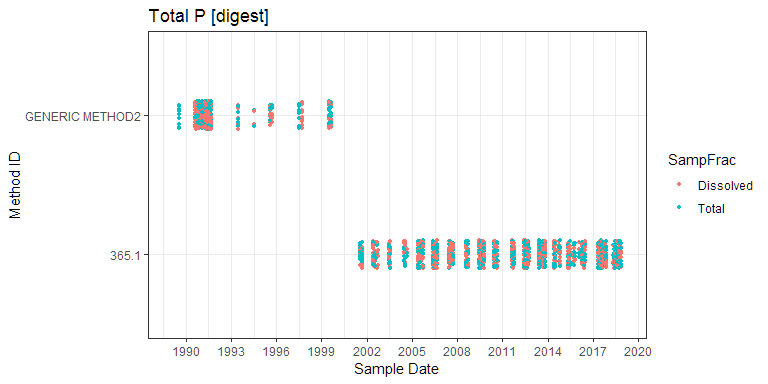

```r
data02 %>% filter(ParamX=="TP") %>%
  ggplot(.,
         aes(y=SDate,
             x=factor(MethodID),
             col=SampFrac)) + theme_bw() +
  geom_point(na.rm=T,
             position=position_jitter(width=0.1), size=1) +
  xlab("Method ID") + ylab("Sample Date") +
  scale_y_date(date_labels ="%Y",
               date_breaks="3 year",
               limits=c(as.Date("1989-01-01"), as.Date("2019-01-01"))) +
  coord_flip() +
  ggtitle("Total P [digest]")
```

```r
#
(
  data02 %>% filter(ParamX=="TP") %>%
  ggplot(.,
         aes(y=SDate,
             x=factor(MethodID),
             col=SampFrac)) + theme_bw() +
  geom_point(na.rm=T,
             position=position_jitter(width=0.1), size=1) +
  xlab("Method ID") + ylab("Sample Date") +
  scale_y_date(date_labels ="%Y",
               date_breaks="3 year",
               limits=c(as.Date("1989-01-01"), as.Date("2019-01-01"))) +
  coord_flip() +ggtitle("Total P [digest]")
) %>% ggsave("UTLK_DP_methods_date_01.jpg", ., height=4, width=10, dpi=500)
```

### 2.2 Patterns of DP in Utah Lake

```r
data02 %>% filter(ParamX=="TP") %>%
  ggplot(.,
         aes(x=SDate,
             y=as.numeric(Result.Value),
             col=SampFrac)) + theme_bw() +
  geom_point(na.rm=T,
             position=position_jitter(width=0.1), size=1) +
  xlab("Sample Date") + ylab("Phosphate-Phosphorus concentration (mg/L)") +
  scale_x_date(date_labels ="%Y",
               date_breaks="3 year",
               limits=c(as.Date("1989-01-01"), as.Date("2019-01-01"))) +
  scale_y_continuous(oob=squish,
                     limits=c(0.002, NA), trans = "log10") +
  geom_point(data=data02%>%filter(ParamX=="TP"&is.na(Result.Value)), na.rm=T,
             aes(x=SDate, y=LRL), color="black", shape="J", size=3) +
  geom_point(data=data02%>%filter(ParamX=="TP"&is.na(Result.Value)), na.rm=T,
             aes(x=SDate, y=MDL), color="red", shape="U", size=3) +
  ggtitle("Total P [digest]")
##
(
  data02 %>% filter(ParamX=="TP") %>%
  ggplot(.,
         aes(x=SDate,
             y=as.numeric(Result.Value),
             col=SampFrac)) + theme_bw() +
  geom_point(na.rm=T,
             position=position_jitter(width=0.1), size=1) +
  xlab("Sample Date") + ylab("Phosphate-Phosphorus concentration (mg/L)") +
  scale_x_date(date_labels ="%Y",
               date_breaks="3 year",
               limits=c(as.Date("1989-01-01"), as.Date("2019-01-01"))) +
  scale_y_continuous(oob=squish,
                     limits=c(0.002, NA), trans = "log10") +
  geom_point(data=data02%>%filter(ParamX=="TP"&is.na(Result.Value)), na.rm=T,
             aes(x=SDate, y=LRL), color="black", shape="J", size=3) +
  geom_point(data=data02%>%filter(ParamX=="TP"&is.na(Result.Value)), na.rm=T,
             aes(x=SDate, y=MDL), color="red", shape="U", size=3) +
  ggtitle("Total P [digest]")
  ) %>% ggsave("UTLK_DP_TP_lowerRnd_date_03.jpg", ., height=6, width=10, dpi=500)
```

[figure not shown]

```r
##
(
  data02 %>% filter(ParamX=="TP") %>%
  ggplot(.,
         aes(x=SDate,
             y=as.numeric(Result.Value),
             col=SampFrac)) + theme_bw() +
  geom_point(na.rm=T,
             position=position_jitter(width=0.1), size=1) +
  xlab("Sample Date") + ylab("Phosphate-Phosphorus concentration (mg/L)") +
  scale_x_date(date_labels ="%Y",
               date_breaks="3 year",
               limits=c(as.Date("1989-01-01"), as.Date("2019-01-01"))) +
  scale_y_continuous(oob=squish,
                     limits=c(NA, 0.1)) +
  geom_point(data=data02%>%filter(ParamX=="TP"&is.na(Result.Value)), na.rm=T,
             aes(x=SDate, y=LRL), color="black", shape="J", size=3) +
  geom_point(data=data02%>%filter(ParamX=="TP"&is.na(Result.Value)), na.rm=T,
             aes(x=SDate, y=MDL), color="red", shape="U", size=3) +
  ggtitle("Total P [digest]")
) %>% ggsave("UTLK_DP_TP_lowerRnd_linscale_date_04.jpg", ., height=4, width=10, dpi=500)
```

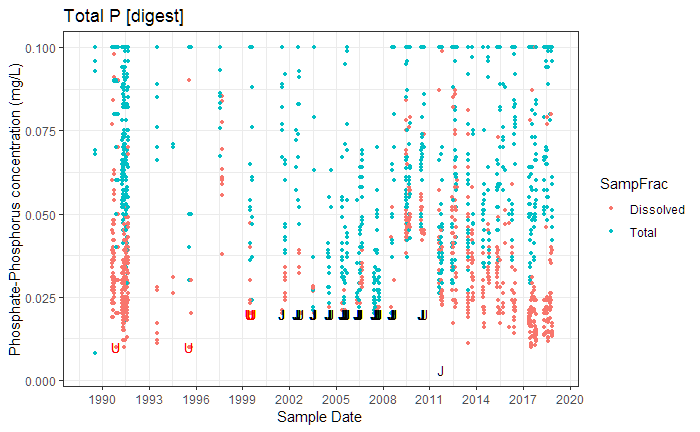

```r
data02 %>% filter(ParamX=="TP") %>%
  ggplot(.,
         aes(x=SDate,
             y=as.numeric(Result.Value),
             col=SampFrac)) + theme_bw() +
  geom_point(na.rm=T,
             position=position_jitter(width=0.1), size=1) +
  xlab("Sample Date") + ylab("Phosphate-Phosphorus concentration (mg/L)") +
  scale_x_date(date_labels ="%Y",
               date_breaks="3 year",
               limits=c(as.Date("1989-01-01"), as.Date("2019-01-01"))) +
  scale_y_continuous(oob=squish,
                     limits=c(NA, 0.10)) +
  geom_point(data=data02%>%filter(ParamX=="TP"&is.na(Result.Value)), na.rm=T,
             aes(x=SDate, y=LRL), color="black", shape="J", size=3) +
  geom_point(data=data02%>%filter(ParamX=="TP"&is.na(Result.Value)), na.rm=T,
             aes(x=SDate, y=MDL), color="red", shape="U", size=3) +
  ggtitle("Total P [digest]")
```

- Dissolved P

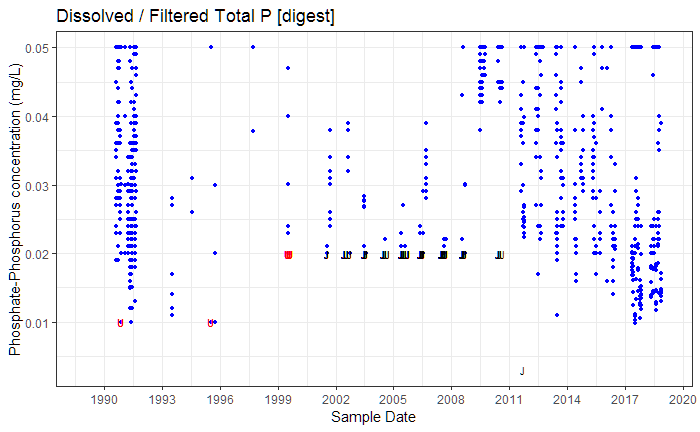

```r
data02 %>% filter(ParamX=="TP" & SampFrac=="Dissolved") %>%
  ggplot(.,
         aes(x=SDate,
             y=as.numeric(Result.Value))) + theme_bw() +
  geom_point(na.rm=T,
             position=position_jitter(width=0.05), size=1, col="blue") +
  xlab("Sample Date") + ylab("Phosphate-Phosphorus concentration (mg/L)") +
  scale_x_date(date_labels ="%Y",
               date_breaks="3 year",
               limits=c(as.Date("1989-01-01"), as.Date("2019-01-01"))) +
  scale_y_continuous(oob=squish,
                     limits=c(NA, 0.050)) +
  geom_point(data=data02%>%filter(ParamX=="TP"&is.na(Result.Value)), na.rm=T,
             aes(x=SDate, y=LRL), color="black", shape="J", size=2.5) +
  geom_point(data=data02%>%filter(ParamX=="TP"&is.na(Result.Value)), na.rm=T,
             aes(x=SDate, y=MDL), color="red", shape="U", size=2.5) +
  ggtitle("Dissolved / Filtered Total P [digest]")
```

- Dissolved P x Method

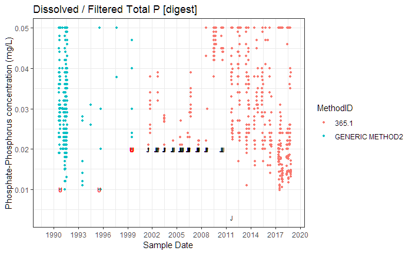

```r
data02 %>% filter(ParamX=="TP" & SampFrac=="Dissolved") %>%
  ggplot(.,
         aes(x=SDate,
             y=as.numeric(Result.Value),
             col=MethodID)) + theme_bw() +
  geom_point(na.rm=T,
             position=position_jitter(width=0.05), size=1) +
  xlab("Sample Date") + ylab("Phosphate-Phosphorus concentration (mg/L)") +
  scale_x_date(date_labels ="%Y",
               date_breaks="3 year",
               limits=c(as.Date("1989-01-01"), as.Date("2019-01-01"))) +
  scale_y_continuous(oob=squish,
                     limits=c(NA, 0.050)) +
  geom_point(data=data02%>%filter(ParamX=="TP"&is.na(Result.Value)), na.rm=T,
             aes(x=SDate, y=LRL), color="black", shape="J", size=2.5) +
  geom_point(data=data02%>%filter(ParamX=="TP"&is.na(Result.Value)), na.rm=T,
             aes(x=SDate, y=MDL), color="red", shape="U", size=2.5) +
  ggtitle("Dissolved / Filtered Total P [digest]")
```

- Dissolved P x Method [2]

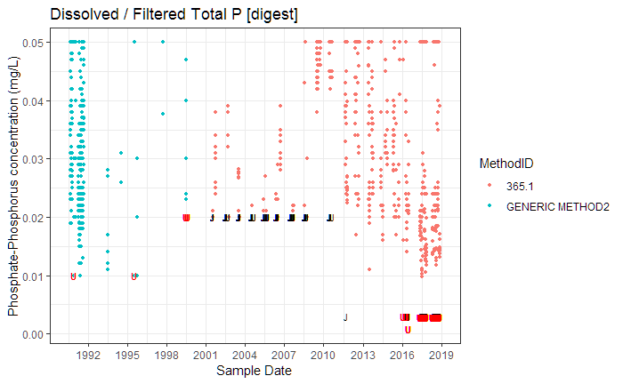

```r
data02 %>% filter(ParamX=="TP" & SampFrac=="Dissolved") %>%
  ggplot(.,
         aes(x=SDate,
             y=as.numeric(Result.Value),
             col=MethodID)) + theme_bw() +
  geom_point(na.rm=T,
             position=position_jitter(width=0.05), size=1) +
  xlab("Sample Date") + ylab("Phosphate-Phosphorus concentration (mg/L)") +
  scale_x_date(date_labels ="%Y",
               date_breaks="3 year",
               limits=c(as.Date("1990-07-01"), as.Date("2019-01-01"))) +
  scale_y_continuous(oob=squish,
                     limits=c(NA, 0.050)) +
  geom_point(data=data02%>%filter(ParamX=="TP"), na.rm=T,
             aes(x=SDate, y=LRL), color="black", shape="J", size=2.5) +
  geom_point(data=data02%>%filter(ParamX=="TP"), na.rm=T,
             aes(x=SDate, y=MDL), color="red", shape="U", size=2.5) +
  ggtitle("Dissolved / Filtered Total P [digest]")
#
(
data02 %>% filter(ParamX=="TP" & SampFrac=="Dissolved") %>%
  ggplot(.,
         aes(x=SDate,
             y=as.numeric(Result.Value),
             col=MethodID)) + theme_bw() +
  geom_point(na.rm=T,
             position=position_jitter(width=0.05), size=1) +
  xlab("Sample Date") + ylab("Phosphate-Phosphorus concentration (mg/L)") +
  scale_x_date(date_labels ="%Y",
               date_breaks="3 year",
               limits=c(as.Date("1990-07-01"), as.Date("2019-01-01"))) +
  scale_y_continuous(oob=squish,
                     limits=c(NA, 0.050)) +
  geom_point(data=data02%>%filter(ParamX=="TP"), na.rm=T,
             aes(x=SDate, y=LRL), color="black", shape="J", size=2.5) +
  geom_point(data=data02%>%filter(ParamX=="TP"), na.rm=T,
             aes(x=SDate, y=MDL), color="red", shape="U", size=2.5) +
    ggtitle("Dissolved / Filtered Total P [digest]")
) %>%
  ggsave("UTLK_DPlower_date_01.jpg", ., height=4, width=10, dpi=500)
```

- Dissolved P x Method [3]

```r
(
data02 %>% filter(ParamX=="TP" & SampFrac=="Dissolved") %>%
  ggplot(.,
         aes(x=SDate,
             y=as.numeric(Result.Value))) + theme_bw() +
  geom_point(data=data02%>%filter(ParamX=="TP"), na.rm=T,
             aes(x=SDate, y=LRL, color=MethodID), shape="J", col="blue", size=2.5) +
  geom_point(data=data02%>%filter(ParamX=="TP"), na.rm=T,
             aes(x=SDate, y=MDL), shape="U", col="red", size=2.5) +
  xlab("Sample Date") + ylab("Phosphate-Phosphorus concentration (mg/L)") +
  scale_x_date(date_labels ="%Y",
               date_breaks="3 year",
               limits=c(as.Date("1990-07-01"), as.Date("2019-01-01"))) +
  scale_y_continuous(oob=squish,
                     limits=c(NA, NA)) +
  geom_vline(xintercept = as.Date("2000-01-01"), lty=2, col="darkgreen", size=1) +
  annotate("text", x=as.Date("1992-01-01"), y=0.016, vjust=0, hjust=0, label="Generic Methods") +
  annotate("text", x=as.Date("2012-01-01"), y=0.016, vjust=0, hjust=0, label="EPA 365.1") +
  ggtitle("Dissolved / Filtered Total P [digest]")
)  %>% ggsave("UTLK_TP_RLs_date_02.jpg", ., height=4, width=10, dpi=500)
```

```r
data02 %>%
  filter(ParamX=="TP" &
           SampFrac=="Dissolved" &
           !grepl("STORET ISN", .$Result.Comment) &
           !is.na(Result.Comment)) %>%
  distinct(Result.Comment)
```

| Result.Comment |
| --- |
| 30-Holding time was exceeded before analysis was completed. \|166-Result supported by re-analysis. |
| 30-Holding time was exceeded before analysis was completed. |
| 124-MatrixSpike %Rec was greater than QC Limit indicating Matrix Interference |
| 166-Result supported by re-analysis. |
| Result Status Updated 190213 from Provisional. Result Status Updated 190213 from Provisional |
| Holding time was exceeded before analysis was completed. |

```r
data02 %>%
  filter(ParamX=="TP" &
           SampFrac=="Dissolved" &
           !grepl("STORET ISN", .$ACT.comment)) %>%
  distinct(ACT.comment)
```

| ACT.comment |
| --- |
| NA |
| Sample Type 2 |
| Sample Type 29 |

### 2.3 Frequency of Data below RL

```r
data02 %>% filter(ParamX=="TP" & SampFrac=="Dissolved") %>%
  group_by(samp_YRqtr, MethodID) %>%
  summarise(Obs = n(),
            p_NonDet = sum(is.na(Result.Value)),
            min_RL = signif(min(LRL, na.rm=T), digits=3),
            max_RL = signif(max(LRL, na.rm=T), digits=3),
            min_DL = signif(min(MDL, na.rm=T), digits=2),
            max_DL = signif(max(MDL, na.rm=T), digits=2)
            ) -> DP_RL_tab01
#
DP_RL_tab01 %<>% mutate(
  NonDet_total = paste(round(p_NonDet / Obs, digits=2)*100,
                       " %", sep="")
  ) %>%
  select(samp_YRqtr:p_NonDet, NonDet_total, everything()) %>%
  mutate(
    min_RL = case_when(
      min_RL == "Inf" ~ as.numeric(NA),
      !is.na(min_RL) ~ min_RL),
    max_RL = case_when(
      max_RL == "-Inf" ~ as.numeric(NA),
      !is.na(max_RL) ~ max_RL
    ),
    min_DL = case_when(
      min_DL == "Inf" ~ as.numeric(NA),
      !is.na(min_DL) ~ min_DL
    ),
    max_DL = case_when(
      max_DL == "-Inf" ~ as.numeric(NA),
      !is.na(max_DL) ~ max_DL
    )
  )

# openxlsx::write.xlsx(DP_RL_tab01, file="DP_reportlimits_table1.xlsx")
```

```r
# DP_RL_tab01 %>%
#   ggplot()

##

DP_RL_tab01 %>%
  htmlTable::htmlTable(., css.cell = rbind(rep("padding-left: 0.8em; padding-right: 0.8em;font-size: 0.75em;", times=ncol(.)+1), matrix("padding-left: 0.75em; padding-right: 0.75em; font-size: 0.75em;", ncol=ncol(.)+1, nrow=nrow(.))))
```

|  | samp_YRqtr | MethodID | Obs | p_NonDet | NonDet_total | min_RL | max_RL | min_DL | max_DL |
| --- | --- | --- | --- | --- | --- | --- | --- | --- | --- |
| 1 | 1990.q03 | GENERIC METHOD2 | 38 | 0 | 0 % |  |  |  |  |
| 2 | 1990.q04 | GENERIC METHOD2 | 50 | 3 | 6 % |  |  | 0.01 | 0.01 |
| 3 | 1991.q01 | GENERIC METHOD2 | 18 | 0 | 0 % |  |  |  |  |
| 4 | 1991.q02 | GENERIC METHOD2 | 103 | 0 | 0 % |  |  |  |  |
| 5 | 1991.q03 | GENERIC METHOD2 | 65 | 0 | 0 % |  |  |  |  |
| 6 | 1993.q03 | GENERIC METHOD2 | 6 | 0 | 0 % |  |  |  |  |
| 7 | 1994.q03 | GENERIC METHOD2 | 2 | 0 | 0 % |  |  |  |  |
| 8 | 1995.q03 | GENERIC METHOD2 | 12 | 2 | 17 % |  |  | 0.01 | 0.01 |
| 9 | 1997.q03 | GENERIC METHOD2 | 11 | 0 | 0 % |  |  |  |  |
| 10 | 1999.q03 | GENERIC METHOD2 | 25 | 18 | 72 % |  |  | 0.02 | 0.02 |
| 11 | 2001.q03 | 365.1 | 21 | 6 | 29 % | 0.02 | 0.02 |  |  |
| 12 | 2002.q02 | 365.1 | 11 | 11 | 100 % | 0.02 | 0.02 |  |  |
| 13 | 2002.q03 | 365.1 | 11 | 6 | 55 % | 0.02 | 0.02 |  |  |
| 14 | 2002.q04 | 365.1 | 3 | 2 | 67 % | 0.02 | 0.02 |  |  |
| 15 | 2003.q03 | 365.1 | 17 | 10 | 59 % | 0.02 | 0.02 |  |  |
| 16 | 2004.q02 | 365.1 | 6 | 6 | 100 % | 0.02 | 0.02 |  |  |
| 17 | 2004.q03 | 365.1 | 9 | 8 | 89 % | 0.02 | 0.02 |  |  |
| 18 | 2005.q02 | 365.1 | 14 | 12 | 86 % | 0.02 | 0.02 |  |  |
| 19 | 2005.q03 | 365.1 | 30 | 28 | 93 % | 0.02 | 0.02 |  |  |
| 20 | 2006.q02 | 365.1 | 26 | 24 | 92 % | 0.02 | 0.02 |  |  |
| 21 | 2006.q03 | 365.1 | 24 | 7 | 29 % | 0.02 | 0.02 |  |  |
| 22 | 2007.q02 | 365.1 | 13 | 13 | 100 % | 0.02 | 0.02 |  |  |
| 23 | 2007.q03 | 365.1 | 37 | 32 | 86 % | 0.02 | 0.02 |  |  |
| 24 | 2008.q03 | 365.1 | 25 | 18 | 72 % | 0.02 | 0.02 |  |  |
| 25 | 2009.q02 | 365.1 | 12 | 0 | 0 % |  |  |  |  |
| 26 | 2009.q03 | 365.1 | 35 | 0 | 0 % |  |  |  |  |
| 27 | 2009.q04 | 365.1 | 9 | 0 | 0 % |  |  |  |  |
| 28 | 2010.q02 | 365.1 | 14 | 4 | 29 % | 0.02 | 0.02 |  |  |
| 29 | 2010.q03 | 365.1 | 20 | 5 | 25 % | 0.02 | 0.02 |  |  |
| 30 | 2011.q03 | 365.1 | 25 | 1 | 4 % | 0.003 | 0.003 |  |  |
| 31 | 2011.q04 | 365.1 | 11 | 0 | 0 % |  |  |  |  |
| 32 | 2012.q02 | 365.1 | 12 | 0 | 0 % |  |  |  |  |
| 33 | 2012.q03 | 365.1 | 34 | 0 | 0 % |  |  |  |  |
| 34 | 2012.q04 | 365.1 | 4 | 0 | 0 % |  |  |  |  |
| 35 | 2013.q02 | 365.1 | 21 | 0 | 0 % |  |  |  |  |
| 36 | 2013.q03 | 365.1 | 46 | 0 | 0 % |  |  |  |  |
| 37 | 2013.q04 | 365.1 | 12 | 0 | 0 % |  |  |  |  |
| 38 | 2014.q02 | 365.1 | 18 | 0 | 0 % |  |  |  |  |
| 39 | 2014.q03 | 365.1 | 23 | 0 | 0 % |  |  |  |  |
| 40 | 2014.q04 | 365.1 | 7 | 0 | 0 % |  |  |  |  |
| 41 | 2015.q02 | 365.1 | 21 | 0 | 0 % |  |  |  |  |
| 42 | 2015.q03 | 365.1 | 14 | 0 | 0 % |  |  |  |  |
| 43 | 2015.q04 | 365.1 | 3 | 0 | 0 % |  |  |  |  |
| 44 | 2016.q01 | 365.1 | 2 | 0 | 0 % | 0.003 | 0.003 | 0.003 | 0.003 |
| 45 | 2016.q02 | 365.1 | 25 | 0 | 0 % | 0.003 | 0.003 | 0.0008 | 0.003 |
| 46 | 2017.q02 | 365.1 | 20 | 0 | 0 % | 0.003 | 0.003 | 0.0028 | 0.0028 |
| 47 | 2017.q03 | 365.1 | 30 | 0 | 0 % | 0.003 | 0.003 | 0.0028 | 0.0028 |
| 48 | 2017.q04 | 365.1 | 20 | 0 | 0 % | 0.003 | 0.003 | 0.0028 | 0.0028 |
| 49 | 2018.q02 | 365.1 | 20 | 0 | 0 % | 0.003 | 0.003 | 0.0028 | 0.0028 |
| 50 | 2018.q03 | 365.1 | 30 | 0 | 0 % | 0.003 | 0.003 | 0.0028 | 0.0028 |
| 51 | 2018.q04 | 365.1 | 18 | 0 | 0 % | 0.003 | 0.003 | 0.0028 | 0.0028 |

## 3.0 Other Parameters…

### 3.1 Calcium

```r
data02 %>% filter(ParamX=="CA") %>%
  {addmargins(table(.$samp_YRqtr, .$MethodID, useNA="ifany", deparse.level = 2),1)} %>%
  htmlTable::htmlTable(., css.cell = rbind(rep("padding-left: 0.8em; padding-right: 0.8em;font-size: 0.75em;", times=ncol(.)+1), matrix("padding-left: 0.75em; padding-right: 0.75em; font-size: 0.75em;", ncol=ncol(.)+1, nrow=nrow(.))))
```

|  | .$MethodID 200.7 | .$MethodID 200.7(W) | .$MethodID 200.8 | .$MethodID GENERIC METHOD |
| --- | --- | --- | --- | --- |
| .$samp_YRqtr |  |  |  |  |
| 1978.q03 | 0 | 0 | 0 | 7 |
| 1989.q03 | 0 | 0 | 0 | 11 |
| 1990.q03 | 0 | 0 | 0 | 38 |
| 1990.q04 | 0 | 0 | 0 | 50 |
| 1991.q01 | 0 | 0 | 0 | 18 |
| 1991.q02 | 0 | 0 | 0 | 102 |
| 1991.q03 | 0 | 0 | 0 | 65 |
| 1993.q03 | 0 | 0 | 0 | 1 |
| 1994.q03 | 0 | 0 | 0 | 2 |
| 1995.q03 | 0 | 0 | 0 | 4 |
| 1997.q03 | 0 | 0 | 0 | 5 |
| 1999.q03 | 0 | 0 | 0 | 6 |
| 2001.q03 | 0 | 4 | 0 | 0 |
| 2002.q02 | 0 | 2 | 0 | 0 |
| 2002.q03 | 0 | 3 | 0 | 0 |
| 2003.q03 | 0 | 4 | 0 | 0 |
| 2004.q02 | 0 | 5 | 0 | 0 |
| 2004.q03 | 0 | 8 | 0 | 0 |
| 2005.q02 | 0 | 5 | 0 | 0 |
| 2005.q03 | 0 | 22 | 0 | 0 |
| 2006.q02 | 0 | 4 | 0 | 0 |
| 2006.q03 | 0 | 2 | 0 | 0 |
| 2007.q02 | 0 | 3 | 0 | 0 |
| 2007.q03 | 0 | 4 | 0 | 0 |
| 2008.q03 | 0 | 10 | 0 | 0 |
| 2009.q02 | 2 | 0 | 0 | 0 |
| 2009.q03 | 6 | 0 | 0 | 0 |
| 2009.q04 | 2 | 0 | 0 | 0 |
| 2010.q02 | 2 | 0 | 0 | 0 |
| 2010.q03 | 4 | 0 | 0 | 0 |
| 2011.q03 | 4 | 0 | 0 | 0 |
| 2011.q04 | 2 | 0 | 0 | 0 |
| 2012.q04 | 2 | 0 | 0 | 0 |
| 2013.q02 | 5 | 0 | 0 | 0 |
| 2013.q03 | 10 | 0 | 0 | 0 |
| 2013.q04 | 12 | 0 | 0 | 0 |
| 2014.q02 | 13 | 0 | 0 | 0 |
| 2014.q03 | 7 | 0 | 0 | 0 |
| 2014.q04 | 2 | 0 | 0 | 0 |
| 2015.q02 | 2 | 0 | 0 | 0 |
| 2015.q03 | 3 | 0 | 0 | 0 |
| 2016.q01 | 1 | 0 | 0 | 0 |
| 2016.q02 | 6 | 0 | 0 | 0 |
| 2017.q02 | 0 | 0 | 20 | 0 |
| 2017.q03 | 0 | 0 | 30 | 0 |
| 2017.q04 | 0 | 0 | 20 | 0 |
| 2018.q02 | 0 | 0 | 20 | 0 |
| 2018.q03 | 0 | 0 | 30 | 0 |
| 2018.q04 | 0 | 0 | 18 | 0 |
| Sum | 85 | 76 | 138 | 309 |

- Method x Date

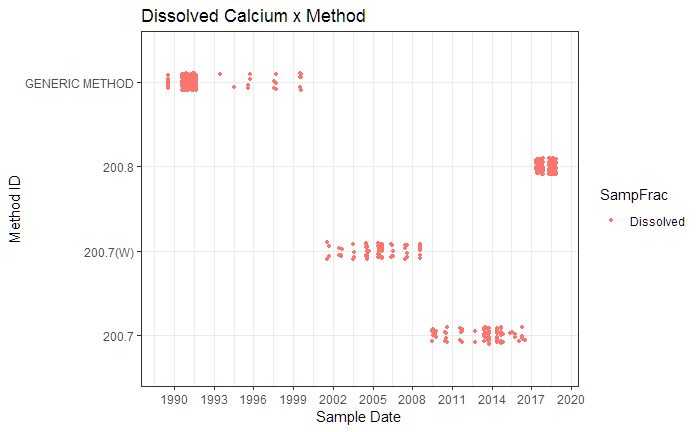

```r
data02 %>% filter(ParamX=="CA") %>%
  ggplot(.,
         aes(y=SDate,
             x=factor(MethodID),
             col=SampFrac)) + theme_bw() +
  geom_point(na.rm=T,
             position=position_jitter(width=0.1), size=1) +
  xlab("Method ID") + ylab("Sample Date") +
  scale_y_date(date_labels ="%Y",
               date_breaks="3 year",
               limits=c(as.Date("1989-01-01"), as.Date("2019-01-01"))) +
  coord_flip() + ggtitle("Dissolved Calcium x Method")
```

- RLs…

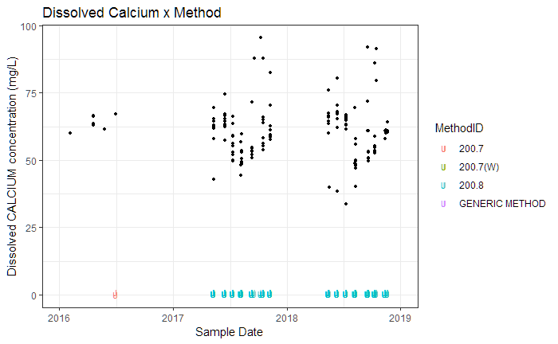

```r
(
data02 %>% filter(ParamX=="CA" & SampFrac=="Dissolved") %>%
  ggplot(.,
         aes(x=SDate,
             y=as.numeric(Result.Value))) + theme_bw() +
  geom_point(na.rm=T,
             position=position_jitter(width=0.05), size=1) +
  geom_point(data=data02%>%filter(ParamX=="CA"), na.rm=T,
             aes(x=SDate, y=LRL, color=MethodID), shape="J", size=2.5) +
  geom_point(data=data02%>%filter(ParamX=="CA"), na.rm=T,
             aes(x=SDate, y=MDL, color=MethodID), shape="U", size=2.5) +
  xlab("Sample Date") + ylab("Dissolved CALCIUM concentration (mg/L)") +
  scale_x_date(date_labels ="%Y",
               date_breaks="1 year",
               limits=c(as.Date("2016-01-01"), as.Date("2019-01-01"))) +
  scale_y_continuous(oob=squish,
                     limits=c(NA, NA)) +
  ggtitle("Dissolved Calcium x Method")
)
```

### 3.2 TSS

```r
data02 %>% filter(ParamX=="TSS") %>%
  {addmargins(table(.$samp_YRqtr, .$MethodID, useNA="ifany", deparse.level = 2),1)} %>%
  htmlTable::htmlTable(., css.cell = rbind(rep("padding-left: 0.8em; padding-right: 0.8em;font-size: 0.75em;", times=ncol(.)+1), matrix("padding-left: 0.75em; padding-right: 0.75em; font-size: 0.75em;", ncol=ncol(.)+1, nrow=nrow(.))))
```

|  | .$MethodID 160.2 | .$MethodID 2540-D |
| --- | --- | --- |
| .$samp_YRqtr |  |  |
| 1978.q03 | 0 | 6 |
| 1989.q03 | 0 | 11 |
| 1990.q03 | 0 | 38 |
| 1990.q04 | 0 | 42 |
| 1991.q02 | 0 | 15 |
| 1991.q03 | 0 | 63 |
| 1993.q03 | 0 | 5 |
| 1994.q03 | 0 | 2 |
| 1995.q03 | 0 | 7 |
| 1997.q03 | 0 | 12 |
| 1999.q03 | 0 | 13 |
| 2001.q03 | 11 | 0 |
| 2002.q02 | 6 | 0 |
| 2002.q03 | 11 | 0 |
| 2002.q04 | 3 | 0 |
| 2003.q03 | 12 | 0 |
| 2004.q02 | 5 | 0 |
| 2004.q03 | 8 | 0 |
| 2005.q02 | 7 | 0 |
| 2005.q03 | 16 | 0 |
| 2006.q02 | 10 | 0 |
| 2006.q03 | 14 | 0 |
| 2007.q02 | 7 | 0 |
| 2007.q03 | 20 | 0 |
| 2008.q03 | 25 | 0 |
| 2009.q02 | 9 | 0 |
| 2009.q03 | 27 | 0 |
| 2009.q04 | 9 | 0 |
| 2010.q02 | 9 | 0 |
| 2010.q03 | 19 | 0 |
| 2011.q03 | 18 | 0 |
| 2011.q04 | 9 | 0 |
| 2012.q02 | 9 | 0 |
| 2012.q03 | 27 | 0 |
| 2012.q04 | 4 | 0 |
| 2013.q02 | 16 | 0 |
| 2013.q03 | 36 | 0 |
| 2013.q04 | 12 | 0 |
| 2014.q02 | 16 | 0 |
| 2014.q03 | 23 | 0 |
| 2014.q04 | 7 | 0 |
| 2015.q02 | 18 | 0 |
| 2015.q03 | 14 | 0 |
| 2015.q04 | 3 | 0 |
| 2016.q01 | 1 | 0 |
| 2016.q02 | 20 | 0 |
| 2017.q02 | 20 | 0 |
| 2017.q03 | 30 | 0 |
| 2017.q04 | 19 | 0 |
| 2018.q02 | 20 | 0 |
| 2018.q03 | 30 | 0 |
| 2018.q04 | 18 | 0 |
| Sum | 598 | 214 |

- Method x Date

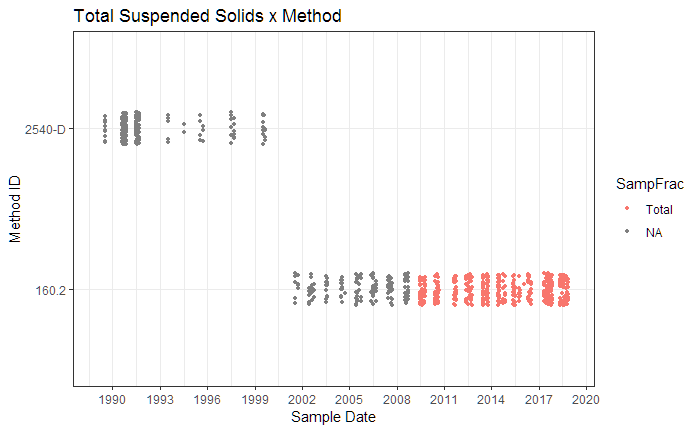

```r
data02 %>% filter(ParamX=="TSS") %>%
  ggplot(.,
         aes(y=SDate,
             x=factor(MethodID),
             col=SampFrac)) + theme_bw() +
  geom_point(na.rm=T,
             position=position_jitter(width=0.1), size=1) +
  xlab("Method ID") + ylab("Sample Date") +
  scale_y_date(date_labels ="%Y",
               date_breaks="3 year",
               limits=c(as.Date("1989-01-01"), as.Date("2019-01-01"))) +
  coord_flip() +
  ggtitle("Total Suspended Solids x Method")
```

- RLs…

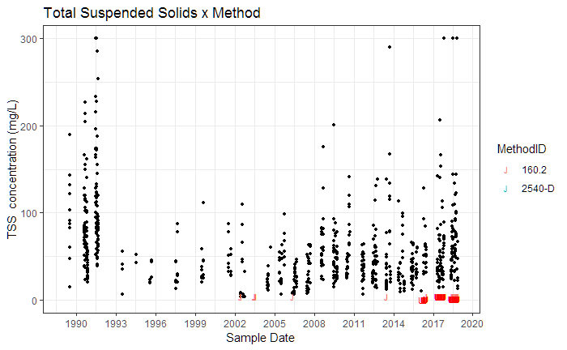

```r
(
data02 %>% filter(ParamX=="TSS") %>%
  ggplot(.,
         aes(x=SDate,
             y=as.numeric(Result.Value))) + theme_bw() +
  geom_point(na.rm=T,
             position=position_jitter(width=0.05), size=1) +
  geom_point(data=data02%>%filter(ParamX=="TSS"), na.rm=T,
             aes(x=SDate, y=LRL, color=MethodID), shape="J", size=2.5) +
  geom_point(data=data02%>%filter(ParamX=="TSS"), na.rm=T,
             aes(x=SDate, y=MDL), shape="U",col="red",  size=2.5) +
  xlab("Sample Date") + ylab("TSS  concentration (mg/L)") +
  scale_x_date(date_labels ="%Y",
               date_breaks="3 year",
               limits=c(as.Date("1989-01-01"), as.Date("2019-01-01"))) +
  scale_y_continuous(oob=squish,
                     limits=c(NA, 300)) +
  ggtitle("Total Suspended Solids x Method")
)
```

### 3.3 Total Alkalinity

```r
data02 %>% filter(ParamX=="T.Alk") %>%
  {addmargins(table(.$samp_YRqtr, .$MethodID, useNA="ifany", deparse.level = 2),1)} %>%
  htmlTable::htmlTable(., css.cell = rbind(rep("padding-left: 0.8em; padding-right: 0.8em;font-size: 0.75em;", times=ncol(.)+1), matrix("padding-left: 0.75em; padding-right: 0.75em; font-size: 0.75em;", ncol=ncol(.)+1, nrow=nrow(.))))
```

|  | .$MethodID 2320-B |
| --- | --- |
| .$samp_YRqtr |  |
| 2009.q02 | 9 |
| 2009.q03 | 27 |
| 2009.q04 | 9 |
| 2010.q03 | 1 |
| 2011.q03 | 3 |
| 2012.q04 | 4 |
| 2013.q03 | 36 |
| 2013.q04 | 12 |
| 2014.q02 | 16 |
| 2014.q03 | 7 |
| 2014.q04 | 7 |
| 2015.q02 | 18 |
| 2015.q03 | 14 |
| 2015.q04 | 3 |
| 2016.q01 | 1 |
| 2016.q02 | 20 |
| 2017.q02 | 20 |
| 2017.q03 | 30 |
| 2017.q04 | 19 |
| 2018.q02 | 20 |
| 2018.q03 | 30 |
| 2018.q04 | 18 |
| Sum | 324 |

- RLs…

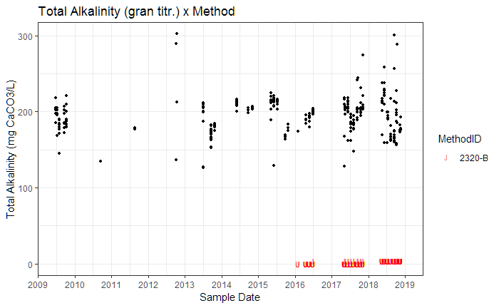

```r
(
data02 %>% filter(ParamX=="T.Alk") %>%
  ggplot(.,
         aes(x=SDate,
             y=as.numeric(Result.Value))) + theme_bw() +
  geom_point(na.rm=T,
             position=position_jitter(width=0.05), size=1) +
  geom_point(data=data02%>%filter(ParamX=="T.Alk"), na.rm=T,
             aes(x=SDate, y=LRL, color=MethodID), shape="J", size=2.5) +
  geom_point(data=data02%>%filter(ParamX=="T.Alk"), na.rm=T,
             aes(x=SDate, y=MDL), shape="U",col="red",  size=2.5) +
  xlab("Sample Date") + ylab("Total Alkalinity (mg CaCO3/L)") +
  scale_x_date(date_labels ="%Y",
               date_breaks="1 year",
               limits=c(as.Date(NA), as.Date("2019-01-01"))) +
  scale_y_continuous(oob=squish,
                     limits=c(NA, NA)) +
  ggtitle("Total Alkalinity (gran titr.) x Method")
)
```

## 4.0 Second retrieval, Nitrogen-species

- Sites as before (see 1.0)
- N-species…
  - NH4
  - NO32
  - TKN
  - TN
  - Norg

### 4.1 AWQMS-data cleanup

```r
# file.02  <- choose.files(caption="Select _working_ DATA file [*.xlsx]", multi = FALSE)
N_data01 <- openxlsx::read.xlsx(file.02, sheet=1, startRow = 2,
                              rowNames=FALSE, check.names = T)
```

- Cleanup

```r
N_data01$Activity.Start.Date <- as.Date(N_data01$Activity.Start.Date, origin="1899-12-30")
N_data01$Analysis.Start.Date <- as.Date(N_data01$Analysis.Start.Date, origin="1899-12-30")
N_data01$Activity.Start.Time <- as.character(chron::times((N_data01$Activity.Start.Time - as.integer(N_data01$Activity.Start.Time))))
N_data01$Analysis.Start.Time <- as.character(chron::times((N_data01$Analysis.Start.Time - as.integer(N_data01$Analysis.Start.Time))))
```

- Filename :: Standard Export 24050.xlsx
- Path :: C:/R_PROJECT_WORK_4
- Datafile has :: 3362 records & 191 fields
- Record Data Range :: From 1990-08-14 to 2018-11-20
- Record Sample-Time Range :: From [08:00:00] to [17:35:00]

#### 4.11 Trim datafile

**Fields to Keep from AWQMS Standard Export**

```r
awqms_export_fields_tokeep <- c("Organization.ID","Activity.ID","Activity.Type","Activity.Media","Activity.Start.Date", "Activity.Start.Time", "Activity.Relative.Depth","Activity.Depth.Height","Activity.Depth.Height.Unit","Activity.Top.Depth.Height","Activity.Top.Depth.Height.Unit","Activity.Bottom.Depth.Height","Activity.Bottom.Depth.Height.Unit","Project.ID1","Project.ID2","Activity.Conducting.Organization1","Activity.Conducting.Organization2","Monitoring.Location.ID","Monitoring.Location.Name","Monitoring.Location.Type","Activity.Comment","Sample.Collection.Method.ID","Sample.Collection.Method.Context","Sample.Collection.Method.Name","Sample.Collection.Method.Description","Result.UID","Data.Logger.Line","Detection.Condition","Characteristic.Name","Method.Speciation","Sample.Fraction","Result.Value","Result.Unit","Result.Qualifier","Result.Status","Value.Type","Time.Basis","Temperature.Basis","Result.Comment","Result.Depth.Height","Result.Depth.Height.Unit","Analytical.Method.ID","Analytical.Method.Context","Analytical.Method.Name","Analytical.Method.Qualifier","Analytical.Method.Description","Laboratory.Name","Analysis.Start.Date","Analysis.Start.Time","Analysis.Start.Time.Zone","Laboratory.Comment.Code","Detection.Limit.Type1","Detection.Limit.Value1","Detection.Limit.Unit1","Detection.Limit.Type2","Detection.Limit.Value2","Detection.Limit.Unit2","Laboratory.Accreditation.Indicator","Substance.Dilution.Factor1","Lab.Batch.ID","Lab.Sample.ID")
```

```r
N_data01 %>% select(., awqms_export_fields_tokeep) -> N_data02
# Simplify VarNames
N_data02 %<>% select(ORG = Activity.Conducting.Organization1,
                   ACTID = Activity.ID,
                   ACT.type = Activity.Type,
                   SDate = Activity.Start.Date, STime = Activity.Start.Time,
                   ACT.depth = Activity.Relative.Depth,
                   PROJ01 = Project.ID1,
                   MLID = Monitoring.Location.ID,
                   MLID.name = Monitoring.Location.Name,
                   MLID.type = Monitoring.Location.Type,
                   ACT.comment = Activity.Comment,
                   DLL = Data.Logger.Line,
                   MethodID = Analytical.Method.ID,
                   PARAM = Characteristic.Name,
                   SampFrac = Sample.Fraction,
                   DetCond = Detection.Condition,
                   ResQual = Result.Qualifier,
                   Result.Value, Result.Status, Result.Comment, Value.Type,
                   Limit01_nm = Detection.Limit.Type1,
                   Limit01_val = Detection.Limit.Value1,
                   Limit02_nm = Detection.Limit.Type2,
                   Limit02_val = Detection.Limit.Value2,
                   DilFact = Substance.Dilution.Factor1,
                   Method_desc = Analytical.Method.Description,
                   LAB = Laboratory.Name,
                   AnalysisDate = Analysis.Start.Date,
                   BatchID = Lab.Batch.ID,
                   PROJ02 = Project.ID2, everything()
                   )
## arrange Var's
N_data02 %<>% select(-ORG, -ACTID, -PROJ01, everything()) %>%
  select(ACT.type:ResQual, Result.Status,
         Result.Value, Limit01_nm, Limit01_val, Limit02_nm, Limit02_val, DilFact,
         everything())
```

#### 4.12 Cleanup Methods and Params

**Parameters**

```r
unique(N_data02$PARAM)
```

```
[1] "Ammonia-nitrogen"                         "Kjeldahl nitrogen"
[3] "Inorganic nitrogen (nitrate and nitrite)" "Organic Nitrogen"
[5] "Nitrogen"
```

```r
N_data02 %<>% mutate(ParamX = PARAM) %>%
  mutate(ParamX = recode(.$PARAM,
                         "Ammonia-nitrogen" = "NH4",
                         "Kjeldahl nitrogen" = "TKN",
                         "Inorganic nitrogen (nitrate and nitrite)" = "NO32",
                         "Organic Nitrogen" = "Norg",
                         "Nitrogen" = "TN")) %>%
  select(ACT.type:PARAM, ParamX, everything())
```

```r
unique(N_data02$MethodID)
```

```
[1] "GENERIC METHOD2" "350.1"           "4500N"           "353.2"           "350.3"
[6] "4500-N-C"        "351.4"
```

```r
unique(N_data02$SampFrac)
```

```
[1] "Total"     "Dissolved"
```

```r
N_data02 %>% {addmargins(table(.$PARAM, .$SampFrac, useNA="ifany"))}
```

```
                                           Dissolved Total  Sum
  Ammonia-nitrogen                               138  1098 1236
  Inorganic nitrogen (nitrate and nitrite)      1004   162 1166
  Kjeldahl nitrogen                                0   259  259
  Nitrogen                                       506   170  676
  Organic Nitrogen                                25     0   25
  Sum                                           1673  1689 3362
```

- Build Meth_Par.key

```r
N_data02 %<>% mutate(
  MethPar.key = paste(.$MethodID,
                      .$ParamX,
                      sep="_"),
  Par_frac = paste(.$ParamX,
                   recode(.$SampFrac,
                          "Dissolved" = "dis",
                          "Total" = "TOT",
                          .missing="TOT"),
                   sep=".")
  ) %>%
  select(-LAB, -ACT.comment, everything()) %>%
  select(ACT.type:MethodID, MethPar.key, Par_frac,
         PARAM:Result.Value, Result.Unit, Result.Comment, ACT.comment, everything())
```

- Add YR_qtr to records

```r
N_data02 %<>% mutate(
  samp_YRqtr = paste(lubridate::year(.$SDate),
                     ".q",
                     sprintf("%.2i",lubridate::quarter(.$SDate, with_year=F)),
                     sep="")) %>%
  select(ACT.type:SDate, samp_YRqtr, everything())
```

- Code Result.Values w/ RLs

```r
unique(N_data02$Limit01_nm)
```

```
[1] NA                         "Method Detection Level"   "Lower Quantitation Limit"
[4] "Lower Reporting Limit"
```

```r
unique(N_data02$Limit02_nm)
```

```
[1] NA                       "Method Detection Level"
```

```r
rlimits = c("Lower Reporting Limit", "Lower Quantitation Limit")
detliits = c("Method Detection Level")


N_data02 %<>% mutate(
  LRL = case_when(
    Limit01_nm %in% rlimits ~ Limit01_val,
    TRUE ~ as.numeric(NA)),
  MDL = case_when(
    Limit01_nm %in% detliits ~ Limit01_val,
    Limit02_nm %in% detliits ~ Limit02_val,
    TRUE ~ as.numeric(NA))) %>%
  select(-MLID.name, -DLL, everything()) %>%
  select(ACT.type:Result.Unit, LRL, MDL,
         Result.Comment:DilFact, MLID.name, everything())
```

### 4.2 Param x Methods

```r
N_data02 %>% {addmargins(table(.$MethPar.key, !is.na(.$Result.Value),
                               useNA="ifany", deparse.level = 2))}
```

```
                      !is.na(.$Result.Value)
.$MethPar.key          FALSE TRUE  Sum
  350.1_NH4              588  241  829
  350.3_NH4               63    1   64
  351.4_TKN                0    4    4
  353.2_NO32             426  486  912
  4500-N-C_TN              1  675  676
  4500N_Norg               0   25   25
  GENERIC METHOD2_NH4    233  110  343
  GENERIC METHOD2_NO32   106  148  254
  GENERIC METHOD2_TKN      0  255  255
  Sum                   1417 1945 3362
```

#### 4.21 Ammonium

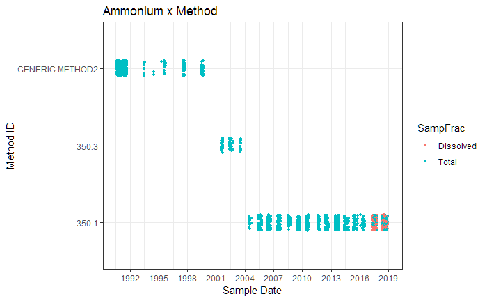

```r
N_data02 %>% filter(ParamX=="NH4") %>%
  ggplot(.,
         aes(y=SDate,
             x=factor(MethodID),
             col=SampFrac)) + theme_bw() +
  geom_point(na.rm=T,
             position=position_jitter(width=0.1), size=1) +
  xlab("Method ID") + ylab("Sample Date") +
  scale_y_date(date_labels ="%Y",
               date_breaks="3 year",
               limits=c(as.Date(NA), as.Date("2019-01-01"))) +
  coord_flip() +
  ggtitle("Ammonium x Method")
```

- Reporting Limits

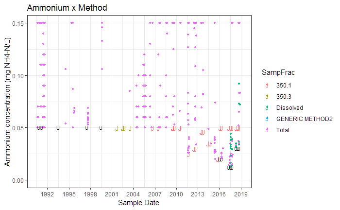

```r
(
N_data02 %>% filter(ParamX=="NH4") %>%
  ggplot(.,
         aes(x=SDate,
             y=as.numeric(Result.Value),
             col=SampFrac)) + theme_bw() +
  geom_point(na.rm=T,
             position=position_jitter(width=0.05), size=1) +
  geom_point(data=N_data02%>%filter(ParamX=="NH4")%>%distinct(samp_YRqtr, .keep_all=T), na.rm=T,
             aes(x=SDate, y=LRL, color=MethodID), shape="J", size=3) +
  geom_point(data=N_data02%>%filter(ParamX=="NH4")%>%distinct(samp_YRqtr, .keep_all=T), na.rm=T,
             aes(x=SDate, y=MDL), color="black", shape="U", size=2) +
  xlab("Sample Date") + ylab("Ammonium concentration (mg NH4-N/L)") +
  scale_x_date(date_labels ="%Y",
               date_breaks="3 year",
               limits=c(as.Date(NA), as.Date("2019-01-01"))) +
  scale_y_continuous(oob=squish,
                     limits=c(0, 0.15)) +
  ggtitle("Ammonium x Method")
)
```

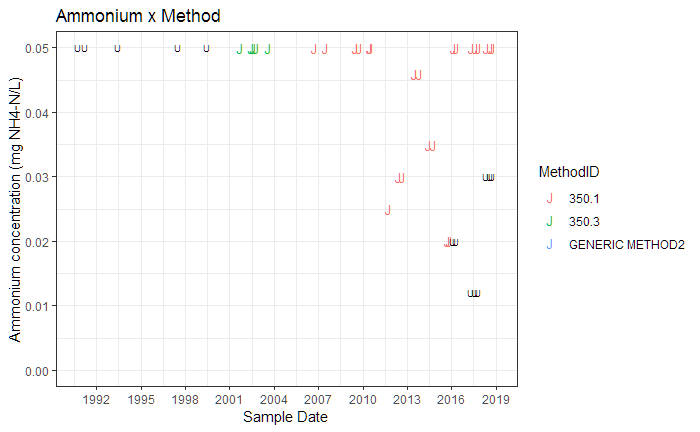

```r
(
N_data02 %>% filter(ParamX=="NH4") %>%
  ggplot(.,
         aes(x=SDate,
             y=as.numeric(Result.Value))) + theme_bw() +
  geom_point(data=N_data02%>%filter(ParamX=="NH4")%>%distinct(samp_YRqtr, .keep_all=T), na.rm=T,
             aes(x=SDate, y=LRL, color=MethodID), shape="J", size=3) +
  geom_point(data=N_data02%>%filter(ParamX=="NH4")%>%distinct(samp_YRqtr, .keep_all=T), na.rm=T,
             aes(x=SDate, y=MDL), color="black", shape="U", size=2) +
  xlab("Sample Date") + ylab("Ammonium concentration (mg NH4-N/L)") +
  scale_x_date(date_labels ="%Y",
               date_breaks="3 year",
               limits=c(as.Date(NA), as.Date("2019-01-01"))) +
  scale_y_continuous(oob=squish,
                     limits=c(0, NA)) +
  ggtitle("Ammonium x Method")
)
```